# Kas būtų jei Lietuva naudotų tik atsinaujinančius energijos išteklius?

Irma Tiškutė

2019-06-15

# Turinys:

## 1. Atsinaujinantys energijos ištekliai

### 1.1 Vėjo energetika

### 1.2 Saulės energetika

### 1.3 Hidroenergija

### 1.4 Biomasės energija

## 2. Lietuvos AEI panaudojimas dabar

### 2.1 AEI naudojimo elektros energijai gaminti skatinimas

## 3. Lietuvos situacija naudojant tik žaliają energiją

# Įvadas

Šiandieniniame pasaulyje vis daugiau žmonių kalba apie žaliają ekonomiką, apie tai, kaip svarbu sumažinti planetos užterštumą ir klimato kaitą. Visus šiuos neigiamus reiškinius daugiausia sukelia elektros energiją ir šilumą gaminančios jėgainės. Siekiant sumažinti išmetamų dujų kiekį į aplinką, pasaulio vasltybės stengiasi iškastinį kurą pakeisti atsinaujinačiais energijos ištekliais (AEI), Lietuva ne išimtis. Pagal šiandieninius nutarimus iki 2030 m. visos Europos Sąjungos naudojama energija privalės būti sudaryta bent iš 27 % atsinaujinančių energijos išteklių. Lietuvos išsikeltas tikslas yra iki 2020 m. naudoti 23 % AEI.

**Darbo objektas -** Atsinaujinančių energijos išteklių panaudojimas Lietuvoje

**Darbo tikslas –** išanalizuoti ir aprašyti kokį poveikį padarytų Lietuvai, jei visą sunaudojamą energiją išgautume iš atsinaujinančių energijos išteklių.

**Darbo uždaviniai:**

1. Išskirti pagrindinius AEI bei jų trūkumus ir privalumus.
2. Aprašyti kokia Lietuvos padėtis yra dabar naudojant AEI.
3. Išanalizuoti kaip paveiktų Lietuvą, jei visiškai atsisakytme iškastinio kuro.

# Atsinaujinantys energijos ištekliai

Šiuo metu pasaulyje yra du paplitę būdai kaip išgauti elektros energiją: iš iškastinio kuro ir iš atsinaujinančių energijos išteklių. Tačiau, pagrindinis iš jų yra iškastinis kuras (nafta, akmens anglis, gamtinės dujos), kurio išmetamos dujos į aplinką sukelia šiltamio efektą ir teršia planetą. Kaip alternatyva buvo sugalvota energiją išgauti iš atsinaujinančių gamtos išteklių (saulės, vėjo, vandens tėkmės, potvynių ir atoslūgių, geoterminės energijos, biomasės augimo). Lietuvoje 2018 m.iš vėjo, saulės jėgainių, hidroelektrinių bei biokuro elektrinių buvo pagaminta 2,09 TWh elektros energijos.

## Vėjo energetika

Vėjo energija - tai viena iš sparčiau besivystančių energijos technologijų, kuri gamina energiją iš vėjo. Svarbus aspektas yra tai, kad vėjo turbinų negalima statyti bet kur ir tikėtis geriausio rezultatų. Reikia atkreipti dėmesį į tai kur yra pastebimi didžiausi ir dažniausiai pasikartojantys vėjo gūsiai. Pirmoji tokio tipo jėgainė Lietuvoje buvo pastatyta tik 2004 m. Kretingos rajone, Vydmantuose. Tačiau, šiuo metu Lietuvoje veikia 23 vėjo jėgainių parkų, kurių bendra galia siekia 480 MW.. Manoma, kad Lietuvoje būtų galima pastatyti apie 6300 vnt. vėjo jėgainių, bet tai reikalautų nemažai lėšų. Vien Lietuvos vėjo elektrinių asociacijos narių investicijos į vėjo energetikos parkus siekia 800 mln. eurų (lvea.lt).

| Privalumai | Trūkumai |
| --- | --- |
| 1. Vėjo ištekliai yra neišsenkantys | 1. Nepastovus energijos gavimas (priklauso nuo vėjo greičio ir dažnio) |
| 2. Neteršia aplinkos nes gamina švarią energiją | 2. Sukelia garsus, kurie nėra malonūs žmonėms |
| 3. Vėjo energijos kainos nuolat mažinamos | 3. Didesnė gamybos savikaina, nei iškastinio kuro |
|  | 4. Vėjo turbinos turi būti statomos netoli vartotojų |
|  | 5. Nesunaudojama visa pagaminta energija |

## Saulės energetika

Tai pats paprasčiausias būdas išgauti energiją, lyginant su kitais AEI. Yra du būdai kaip išgauti energiją iš saulės. Pirmasis su saulės kolektorių pagalba, o kitas su saulės baterijomis arba dar kitaip vadinamomis fotovoltinėmis baterijomis. Kadangi saulės kolektorius galima statyti ant kiekvieno namo stogo, tai puiki alternatyva tiems žmonėms, kurie nori būti nepriklausomi nuo energijos tiekimo. Dėja tai nėra pigu, todėl Lietuvoje naudojant saulės energetiką, yra išgaunama labai maža dalis energijos.

| Privalumai | Trūkumai |
| --- | --- |
| 1. Neišsenkantis energijos šaltinis | 1. Nepastovus būdas išgauti energijai, nes priklauso nuo meteorologinių sąlygų |
| 2. Draugiškas aplinkai | 2. Nepagamina pakankamai energijos arba susidaro perteklius |
| 3. Gali būti įrengiami kiekvienuose gyvenamuosiuose namuose | 3. Brangus įrengimas, kuris reikalauja nemažai piniginių išteklių |
|  | 4. Neišgaunama pakankamai energijos aprūpinti didžiają dalį namų ūkio |

## Hidroenergija

Hidroenergija yra pigiausia iš visų atsinaujinančių energijos išteklių, bei yra nepertraukiama dėl nuolatinės vandens tėkmės. Tačiau jos įrengimas ir priežiūra reikalauja nemažai lėšų. Geoterminės energijos pagaminta energija generuoja nuolatinę galią, nes jos ištekliai yra giliai po žeme. Tačiau dėl technologinių apribojimų ne visur šie ištekliai gali būti panaudoti energijai gaminti (Bužinskienė 2018, 47). Lietuvoje hidroelektrinės yra panaudojamos apie 25-35%.

| Privalumai | Trūkumai |
| --- | --- |
| 1. Nereikalaujanti didelių lėšų elektros energijos gamyba | 1. Daro neigiamą poveikį vandens ekosistemai |
| 2. Neišmeta į aplinką kenksmingų dujių | 2. Nevienodas elektros energijos gavimo būdas dėl sausrų ir potvynių |
| 3. Nepertraukiamas elektros energijos gavimo būdas |  |

## Biomasės energija

Šiai energijai išgauti yra naudojamos įvairios organinės medžiagos, tokios kaip mediena, žemės ūkio atliekos (šiaudai, rapsai, kviečiai), paukščių ar gyvulių ekskrementai bei maisto ir komunalinės atliekos. Kadangi kietą medžiagą yra lengviau paruošti kūrenimui, nei skysto ar dujinio pavidalo, tad labiau yra įprasta naudoti pasaulyje medieną. Tačiau taip pat teigiama, kad energijai iš biokuro išgauti reikia itin daug žemės ir vandens sąnaudų (Kolesinskas 2015, 12). Lietuva palyginus su kitomis EU šalimis yra gana miškingas kraštas, tad vis daugiau lietuvių renkasi naudoti biokurą. Lietuvos valstybė norėdama paskatinti biokuro naudojimą, vartotojams ir naudotojams yra sudariusi įvairių lengvatų ir finansavimų. Kaip ir dauguma kitų atsinaujinančių energijos išteklių, taip ir ši nėra pilnai išnaudojama.

| Privalumai | Trūkumai |
| --- | --- |
| 1. Biokuras yra pigesnis nei iškastinis kuras | 1. Paruošti biomasę reikalauja nemažai laiko |
| 2. Neteršia aplinkos nes gamina švarią energiją | 2. Reikalingas didelis žemės plotas |
| 3. Nuolat gaminami biokuro ištekliai |  |
| 4. Mažina įvairias nereikalingas atliekas |  |

# Lietuvos AEI panaudojimas dabar

Remiantis Lietuvos statistikos departamento duomenimis 2018 m. gruodžio 8 d. Lietuvoje veikia apie 3555 elektrinių, turinčios leidimus gaminti elektros energiją iš atsinaujinančių energijos išteklių (enmin.lrv.lt). Visų įrengtų elektrinių bendra suminė įrengtoji galia siekia – 839 MW:

- 200 vėjo jėgainių, kurių suminė instaliuota galia sudaro 533 MW;
- 3050 saulės šviesos energiją naudojančių elektrinių, kurių suminė galia – 88 MW;
- 102 hidro elektrinės, kurių suminė galia – 128 MW;
- 40 biodujų, 1 komunalinių atliekų, 162 vnt. biomasės elektrinių, kurių suminė galia – 90 MW.

```r
if(!require(rsdmx)) install.packages("rsdmx"); require(rsdmx)
if(!require(openxlsx)) install.packages("openxlsx"); require(openxlsx)
if(!require(eurostat)) install.packages("eurostat"); require(eurostat)
if(!require(tidyverse)) install.packages("tidyverse"); require(tidyverse)
meta <- readSDMX("https://osp-rs.stat.gov.lt/rest_xml/dataflow/")
meta <- as.data.frame(meta)

write.xlsx(meta, "LSD_meta.xlsx")
```

```
## Note: zip::zip() is deprecated, please use zip::zipr() instead
```

```r
S1R094_M8020313 <- readSDMX(providerId = "LSD",
                            resource = "data",
                            flowRef = "S1R094_M8020313",
                            dsd = TRUE)
```

```
## -> Fetching 'https://osp-rs.stat.gov.lt/rest_xml/data/S1R094_M8020313/all/'
```

```
## -> DSD ref identified in dataset = 'M8020313'
```

```
## -> Attempt to fetch & bind DSD to dataset
```

```
## -> Fetching 'https://osp-rs.stat.gov.lt/rest_xml/datastructure/all/M8020313/latest/?references=children'
```

```
## -> DSD fetched and associated to dataset!
```

```r
S1R094_M8020313 <- as.data.frame(S1R094_M8020313, label = TRUE)
```

```r
df <- S1R094_M8020313 %>%
  filter(!(elektros_irenginiai_label.lt %in% c("Geoterminiai įrenginiai", "Visi elektros energijos gamybos įrenginiai", "Termofikacinė pramoninių ir komunalinių atliekų jėgainė")),
         MATVNT=="GWh",
         LAIKOTARPIS>="2010") %>%
  select(-c(1,2,7:10))
```

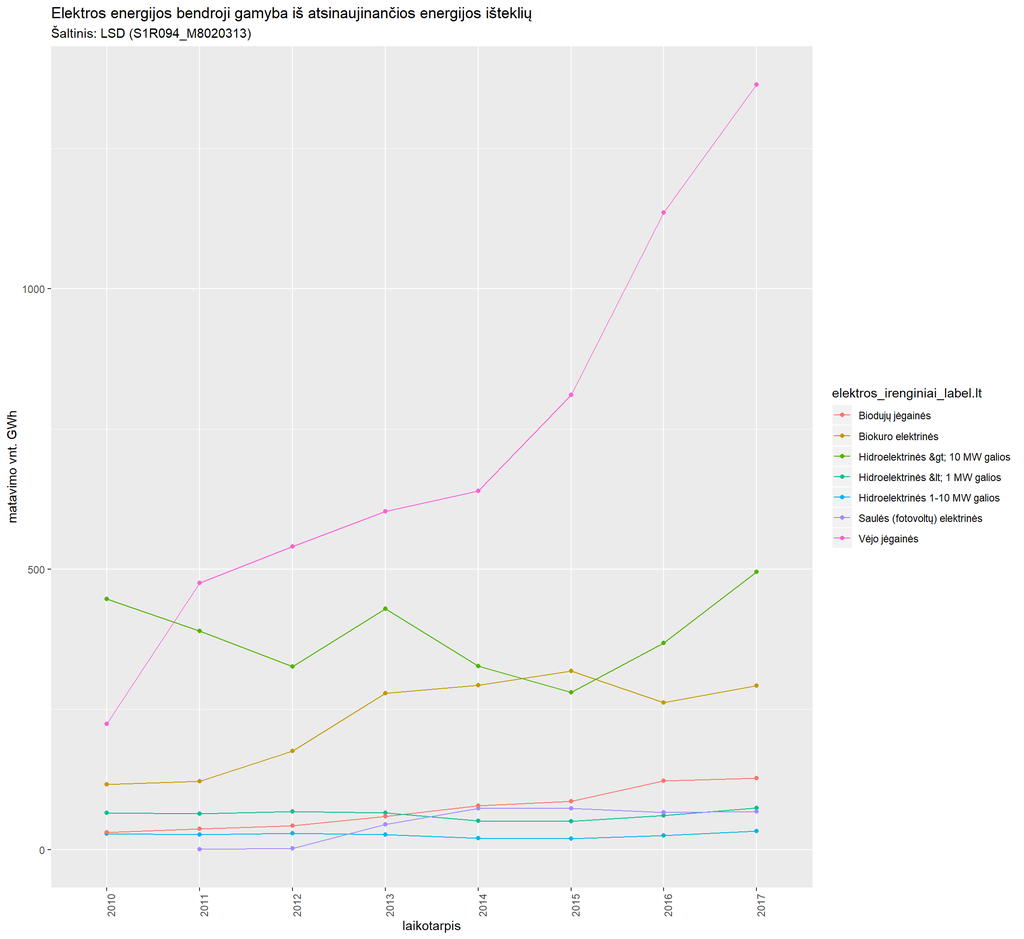

```r
ggplot(df, aes(x=LAIKOTARPIS, y=obsValue, col=elektros_irenginiai_label.lt, group=elektros_irenginiai_label.lt))+
  geom_line()+
  geom_point()+
  theme(axis.text.x = element_text(angle = 90, hjust = 1))+
   labs(title = "Elektros energijos bendroji gamyba iš atsinaujinančios energijos išteklių",
       subtitle = "Šaltinis: LSD (S1R094_M8020313)",
       x="laikotarpis",
       y="matavimo vnt. GWh")
```

Nors ir didžiają dalį elektros energijos iš AEI yra pagaminama vėjo jėgainių. Tačiau tai nėra pakankamai didelė pagaminama energijos dalis iš AEI, todėl daugiau kaip 70 % elektros energijos iš iškastinio kuro buvo importuota iš kaimyninių valstybių. Remiantis sudarytos lentelės duomenimis “Lietuvos atsinaujinančių išteklių energijos dalis %”, nuo 2004 m. Lietuva ganėtinai daug yra pasistumėjusi elektros energijos gamyboje iš AEI. Nors ir nuo 2015 m. iki 2017 m. procentinė dalis pakito nežymiai tik per 0,084 %, tačiau jau 2014 m. Lietuva pasiekė savo išsikelta tikslą iki 2020 m. pagaminti 23 % elektros energijos iš AEI.

```r
nrg_ind_ren <- get_eurostat("nrg_ind_ren", stringAsFactors=FALSE)
```

```
## Table nrg_ind_ren cached at C:\Users\Admin\AppData\Local\Temp\Rtmp0CIxBj/eurostat/nrg_ind_ren_date_code_TF.rds
```

```r
ef <- nrg_ind_ren %>% filter((geo=="LT"),
                             nrg_bal=="REN",
                             time>="2004-01-01",
                             unit=="PC")
```

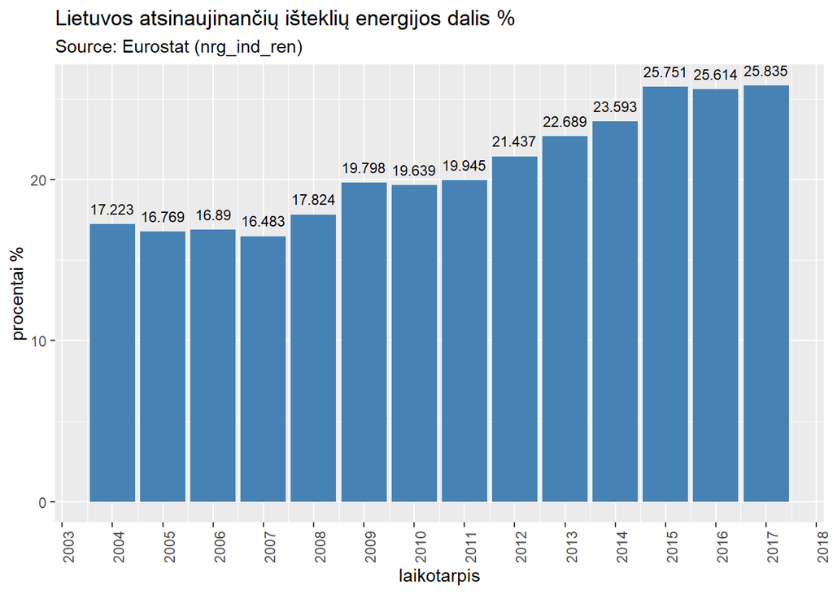

```r
ggplot(ef, aes(x=time, values))+
  geom_bar(stat="identity",
           fill="steelblue")+
  scale_x_date(date_labels = "%Y", date_breaks = "1 year")+
  theme(axis.text.x = element_text(angle = 90, hjust = 1))+
  geom_text(aes(label=values), vjust=-0.9, size=3.0)+
  labs(title = "Lietuvos atsinaujinančių išteklių energijos dalis %",
       subtitle = "Source: Eurostat (nrg_ind_ren)",
       x="laikotarpis",
       y="procentai %")
```

## AEI naudojimo elektros energijai gaminti skatinimas

Valstybė norėdama paskatinti žmones naudoti ir gaminti atsinaujinančius energijos išteklius yra paruošusi įvairių finansavimų, paramų ir konkursų. Vienas iš jų yra: [g]amintojai naudojantys atsinaujinančius energijos išteklius gali pretenduoti į paramą, kuri finansuojama Viešuosius interesus atitinkančių paslaugų (VIAP) biudžeto lėšomis. (enmin.lrv.lt) Ši parama suteikiama 12 metų laikotarpiui. Išviso nuo 2010 iki 2018 metų VIAP buvo paruošusi 1568 mln. lėšų, kurių didžioji dalis atiteko „Lietuvos energijos“ įmonei. Yra siūloma kurti atsinaujinančių energijos bendrijas, kurias sudarytų šalies gyventojai arba iš kaiminysčių susikūrusios bendrijos. Jos galėtų statyti saulės kolektorius ne tik ant būtų, namų stogų, bet ir šalia esančiuose sklypuose, kad pagaminama elektros energija pilnai aprūpintų namo gyventojus. Iš šio projekto žmonės galėtų dar ir uždirbti, bei gautą pelną skirti bendruomenės tikslams. Susidariusį elektros energijos perteklių galėtų parduoti elektros energijos biržoje ar kitiems vartotojams. Tačiau didžiają dalį lėšų atsinaujinantiems energijos ištekliams plėsti skiria EU. Remiantis paskutiniais duomenimins iš esinvesticijos.lt galima teigti, kad ES struktūrinių fondų lėšos siekė 23 338 114,00 Eur., tad norint labiau prisidėti prie AEI vartojimo skatinimo, Lietuvos valstybė turėtų skirti didesnę lėšų dalį.

# Lietuvos situacija naudojant tik žaliają energiją

Šiuo metu Lietuva gamina tik labai nedidelę dalį elektros energijos iš AEI, tačiau po 70 metų yra manoma, kad valstybė visiškai atsisakys iškastinio kuro ir 100 proc. elektos energijos bus gaminama iš AEI. Tad svasrtoma kokių pokyčių tai atneš Lietuvai ir ar bus gaugiau teigiamų aspektų nei neigiamų. Tai visų pirma Lietuva stipriai prisidėtų prie aplinkos taršos mažinimo, kadangi nebūtų į orą išmetama tiek daug teršalų, skatinančių klimato kaitą. To pasekoje populiarumo turėtų sulaukti ir elektromobiliai, kurie nebereikalautų tokių didelių lėšų kaip daabr ir jį galėtų įsigyti daugelis. Visų antra Lietuva taptu nepriklausoma nuo kitų valstybių elektros atžvilgiu. Taip sumažėtų importo išlaidos, kurias galėtų skirti atsinaujinančių išteklių plėtojimui, bei valstybė pati, atsižvelgdama į kaštus, galėtų nustatyti elektros kainą. Trečias teigiamas dalykas yra tai, kad būtų sukuriama daug naujių darbų vietų, nes reikėtų žmonių, kurie įrenginėtų AEI technologijas, bei prireikus jas tvarkytų ir žinoma reikėtų asmenų, kurie nuolat prižiūrėtų, kad būtų nenutrūkstamas elektros tiekimas. Taip pat yra žinomas faktas, kad ne visa elektros energija pagaminta iš AEI yra suvartojama, tad šį perteklių galėtų parduoti kaimyninėms šalims ir taip padidinti valstybės biudžetą. Žinoma, atsirastų ir neigiamų aspektų. Vienas iš jų yra tai, kad valstybei tektų gauti nemažą finansavimą iš EU, bei pačiai skirti daug lėšų atsinaujinančių išteklių įrenginių įrengimui. Todėl, kol nebus energija gaunama vien tik iš AEI, elektros kainos gali būti didelės, kol valstybei atsipirks investicijos. Prieš įrenginėjant vėjo jėgaines ar saulės baterijas, kolektorius reikės skirti nemažą ploto dalį, bei atsižvelgti į tai, kad šalia nebūtų daug gyvenamųjų namų, nes žmonės gali piktintis dėl vėjo turbinų skleidžiamų garsų. Kitų manymų AEI įrenginiai darko kraštovaizdį ir neprideda jokio estetinio vaizdo. Nors ir išpradžiu diegiant AEI įrenginius reiktų investuoti nemažą dalį lėšų, tačiau laikui bėgant tai turėtų atsipirkti, tiek ekologiška, finansine ir socialine prasme (Kolesinskas 2015, 12–14).

# Išvados

1. Lietuvos išsikeltas tikslas yra iki 2020 m. gaminti 23 % elektros energijos iš AEI, tačiau šią procentinę dalį pasiekė jau 2014 m.
2. Daugiausia elektros energijos iš AEI pagamina vėjo jėgainės.
3. Dažnai susidaro elektros energijos perteklius gautas iš AEI, kuris nėra panaudojamas (taip išvaistoma energija).
4. Norint visiškai pakeisti iškastinį kurą atsinaujonančiais energijos ištekliais, reikia tam skirti daug lėšų, bei prašyti EU didesnės paramos, tačiau galų gale tai turėtų atsipirkti vasltybei.
5. Jeigu Lietuva gamintų elektros energiją naudodama 100 % AEI, tai valstybei atneštų ekologiška, finansine ir socialine naudą.
6. Kuo daugiau Lietuva gamins elektros energiją iš AEI, tuo vis mažiau taps priklausoma nuo kitų valstybių.
7. Dabar dar nebūtų įmanoma visiškai atsisakyti iškastinio kuro, nes AEI prietaisai nėra pakankamai ištobulinti.

# Šaltiniai

Duomenys:

- Share of energy from renewable sources (Eurostat, https://appsso.eurostat.ec.europa.eu/nui/show.do?dataset=nrg_ind_ren&lang=en)
- Elektros energijos bendroji gamyba iš atsinaujinančios energijos išteklių (LSD, https://osp.stat.gov.lt/lt/statistiniu-rodikliu-analize?hash=03918f64-e56d-46cc-9ee1-55c9b38b6fdd (S1R094_M8020313))

Literatūros sąrašas:

- Technologijos.lt(2019). *Lietuvoje žmonės galės burtis į atsinaujinančios energijos bendrijas - kas tai yra ir kokia nauda?* Prieiga per internetą: http://www.technologijos.lt/n/technologijos/energija_ir_energetika/S-74509/straipsnis/Lietuvoje-zmones-gales-burtis-i-atsinaujinancios-energijos-bendrijas---kas-tai-yra-ir-kokia-nauda (žiūrėta 2019 birželio 17)
- Enmin.lrv.lt(2018). *Statistika* Prieiga per internetą: https://enmin.lrv.lt/lt/veiklos-sritys-3/atsinaujinantys-energijos-istekliai/statistika (žiūrėta 2019 birželio 17)
- Esinvesticijos.lt (2019). *Patvirtintos priemonės* Prieiga prie interneto: https://www.esinvesticijos.lt/lt/patvirtintos_priemones/atsinaujinantys-energijos-istekliai-pramonei-lt (žiūrėta 2019 birželio 17)
- Lvea.lt *Lietuvos statistika* Prieiga prie interneto: https://lvea.lt/statistika/lietuvos-statistika/ (žiūrėta 2019 birželio 17)
- Zec.lt *Žalioji energetika* http://www.zec.lt/ (žiūrėta 2019 birželio 17)

Bužinskienė, Rita. 2018. “Atsinaujinančių Energijos Išteklių Panaudojimo Vertinimas.”

Kolesinskas, Vytautas. 2015. “ES Alternatyvios Elektros Energetikos Paramos Finansavimo šaltinių Naudingumo Vertinimas.” PhD thesis, Vytautas Magnus University.